# ANALYZING THE IMPACT OF DEMOGRAPHIC CHARACTERISTICS ON THE STABILITY PLACEMENTS IN FOSTER CARE HOMES: A MULTIVARIATE APPROACH TO IDENTIFY DISPARITIES AND INFORMING POLICY

# Setup

```r
library(readxl)
library(ggplot2)
library(dplyr)
library(stargazer)
```

```r
Child <- read_excel("ESU Data Share 12.7.23.xlsx")
View(Child)
```

# INTRODUCTION

In conclusion, this research underscores the critical need for a foster care system that is equitable, culturally competent and responsive to the diverse needs of all children. By addressing the disparities identified through our analysis, we can work towards a future where every child in foster care has the opportunity for a stable, nurturing and permanent home. Our findings and recommendations provide a foundation for policymakers and child welfare practitioners to develop targeted interventions that can significantly improve the experiences and outcomes of children in foster care.

```r
sapply(Child, class)
```

```
       Case ID Number      Family ID Number         AgeatReferral                Gender
          "character"           "character"             "numeric"           "character"
            Ethnicity            Disability TotalNumberofRemovals         RemovalReason
          "character"           "character"             "numeric"           "character"
      DischargeReason     ExitedfromKVCCare
          "character"           "character"
```

```r
summarize_all(Child, function(x) sum(is.na(x)))
```

| Case ID Number | Family ID Number | AgeatReferral | Gender | Ethnicity | Disability | TotalNumberofRemovals | RemovalReason | DischargeReason | ExitedfromKVCCare |
| --- | --- | --- | --- | --- | --- | --- | --- | --- | --- |
| 0 | 3 | 0 | 285 | 87 | 1415 | 0 | 74 | 1468 | 0 |

The completeness and accuracy assessment of the data reveals the following:

Family ID Number: 3 missing values

Gender: 285 missing values

Ethnicity: 87 missing values

Disability: 1415 missing values

Removal Reason: 74 missing values

Discharge Reason: 1468 missing values

High rates of missing data in certain columns, such as Disability and Discharge Reason, can introduce bias. If data is more likely to be missing for certain groups of people, this can skew results and lead to inaccurate conclusions. The inconsistencies in categorical variables, such as those found in Ethnicity and Disability, can lead to misclassification or inaccurate grouping of individuals. This can dilute or falsely amplify perceived differences or similarities between groups in the analysis. Unclear categories in Ethnicity and Disability might not accurately reflect individuals’ identities or conditions, leading to potential misrepresentation or oversimplification of complex identities and conditions. The reasons for removal and discharge might be subject to reporting biases, where certain reasons are more likely to be reported than others due to subjective interpretations, stigma, or legal implications. The dataset primarily focuses on individual characteristics and case details without providing broader social, economic, or community context. This limitation might prevent understanding the full scope of factors influencing the care process and outcomes. The data provides a snapshot at a specific point in time (e.g., at referral or discharge) without longitudinal tracking that could offer insights into changes over time or the effectiveness of interventions. To mitigate these effects, it’s important to employ strategies such as: 1. Cleaning and imputation of the data can address the missing values and inconsistencies of the data using techniques that consider the underlying mechanisms of missingness or error. 2. Conducting sensitivity analyses under different assumptions about missing data and categorization to understand how these factors might affect the results. 3. Consulting stakeholders from diverse backgrounds to interpret data and results in a way that is sensitive to different experiences and needs. 4. Clearly communicate the limitations and potential biases of the data in any analysis or reporting, highlighting how they might influence interpretations and recommendations.

# Age Distribution

```r
# Summary statistics for Age at Referral
summary(Child$`AgeatReferral`)
```

```
   Min. 1st Qu.  Median    Mean 3rd Qu.    Max.
  0.000   2.000   7.000   7.231  12.000  21.000
```

```r
sd(Child$`AgeatReferral`)
```

```
[1] 5.54509
```

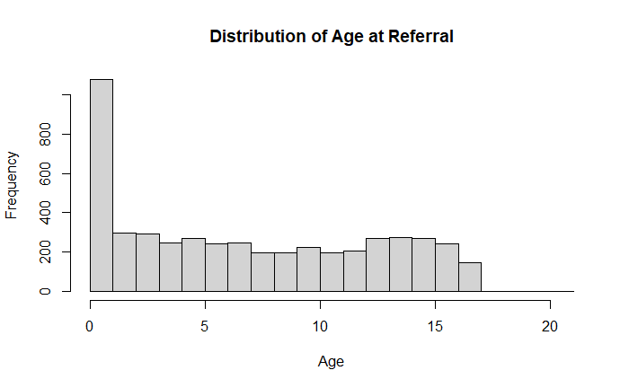

```r
# Optional: Plot a histogram to visualize the age distribution
hist(Child$`AgeatReferral`, main="Distribution of Age at Referral", xlab="Age", breaks=20)
```

# Distribution of Gender

```r
# Frequency table for Gender
table(Child$Gender, useNA="ifany")
```

```
   F    M <NA>
2302 2315  285
```

# Distribution of Ethnicity

```r
# Frequency table for Ethnicity
table(Child$Ethnicity, useNA="ifany")
```

```
AFAM AMIN ASIA BIRA    C   CA CAIC  CAU CAUC HISP   ME OTHE UNKN <NA>
 869  187   43  306   16    2    1    1 3227   94    1   67    1   87
```

# Frequency of Top Removal Reasons

```r
# Top 5 Removal Reasons
removal_reasons <- table(Child$`RemovalReason`)
sort(removal_reasons, decreasing = TRUE)[1:5]
```

```
                                             UnableProvideCare
                                                           521
                                                 PhysicalAbuse
                                                           202
                                         ChildsBehaviorProblem
                                                           109
LackofSupervision, ParentalDrugAbuse, PrntGrdnIssueDrgsAlcohol
                                                            87
                                             LackofSupervision
                                                            85
```

# Frequency of Top Discharge Reasons

```r
# Top 5 Discharge Reasons
discharge_reasons <- table(Child$`DischargeReason`)
sort(discharge_reasons, decreasing = TRUE)[1:5]
```

```
                         ADOPTION                     REINTEGRATION COURT RECOMMENDED - REINTEGRATION
                              982                               669                               645
        AGED OUT - OPPLA ACHIEVED                     CUSTODIANSHIP
                              386                               106
```

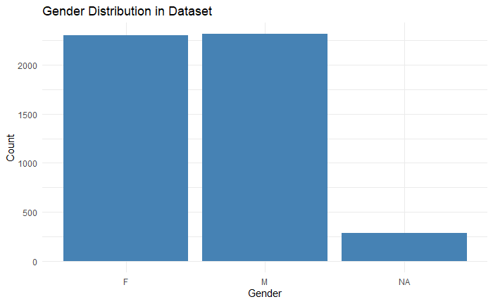

```r
gender_distribution <- ggplot(Child, aes(x=Gender)) +
  geom_bar(fill="steelblue") +
  theme_minimal() +
  labs(title="Gender Distribution in Dataset", x="Gender", y="Count")

print(gender_distribution)
```

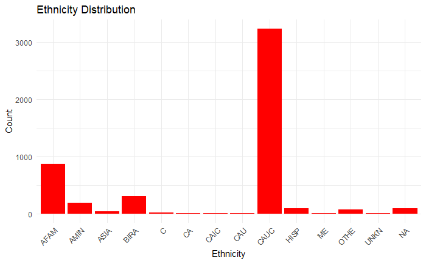

```r
library(ggplot2)

# Replace `data` with your actual dataframe name if it's different
ethnicity <- ggplot(Child, aes(x=`Ethnicity`)) +
  geom_bar(fill="red") +
  theme_minimal() +
  labs(title="Ethnicity Distribution", x="Ethnicity", y="Count") +
  theme(axis.text.x = element_text(angle=45, hjust=1)) # Adjust text angle for better readability

print(ethnicity)
```

The bar chart depicts the count of individuals by ethnicity in the dataset, with several ethnic categories presented. The CAUC- White/Caucasian ethnicity category is significantly more represented than others, indicating a majority within this group. This distribution could impact service delivery and resource allocation in the foster care system, needing cultural competency. The presence of an “UNKNOWN” and “NA” category suggests some data on ethnicity is missing or was not collected. Examine how ethnicity relates to other factors such as length of stay or discharge outcomes. Address gaps in ethnicity data collection.

# Background

Stability in foster care is essential for the emotional, psychological, and educational well-being of children. Frequent changes in foster placements can cause significant disruptions, leading to attachment issues, increased anxiety, and educational discontinuity. These factors collectively hinder a child’s ability to develop healthy social skills, potentially affecting their future employment and social relationships. Stable foster care experiences not only improve immediate outcomes for children but also help in breaking the cycles of abuse and neglect, decreasing the likelihood of involvement in criminal activities and substance abuse. Additionally, stable placements promote better resource management within the child welfare system, reduce the administrative load, and improve the morale and retention of social workers and caregivers.By focusing on the factors that enhance placement stability, policymakers can develop more effective laws and support systems. This includes bolstering resources for foster families, refining training programs, and optimizing matching processes. Stability is not only a measure of system performance but also a foundation for implementing evidence-based practices. Ultimately, fostering stability in placements is about upholding children’s rights to a supportive and consistent environment, aiding their development into well-rounded adults. It supports family reunification efforts where possible and provides a clearer path to adoption or permanent guardianship when necessary. Addressing this issue is crucial for enhancing the overall quality of life for children in foster care and for shaping effective, humane child welfare policies and practices. The stability of placements within the foster care system plays a pivotal role in affecting the developmental and well-being outcomes for foster children. A considerable volume of research has been focused on understanding the factors influencing placement stability and the consequences of placement changes. This literature review synthesizes findings from key studies, highlighting the major themes and identifying gaps in the accumulated knowledge. Several studies have identified a range of factors that influence the stability of foster care placements. These factors can be categorized into child-related, caregiver-related and systemic factors. The presence of behavioral and emotional problems referenced by Newton et al. (2000) and Konijn et al. (2019) and adverse childhood experiences highlighted by Liming et al. (2021) have been associated with increased placement instability. Harden (2004) underscores the critical need to focus on the developmental requirements of foster children, advocating that their growth is fundamentally dependent on ensuring their safety and stability. The characteristics and resources of foster caregivers’ impact placement stability. Vanderwill et al. (2021) carried out an extensive review which pointed out that factors related to caregivers, including their capacity to fulfill the needs of foster children, dedication, and available support networks, play a vital role in improving the stability and long-term nature of placements. Systemic and organizational aspects of the foster care system also play a significant role in placement stability. Gypen et al. (2017) and Hernandez-Mekonnen (n.d.) point towards the need for systemic improvements to address placement instability, including policy changes and better support for foster families. Research consistently shows that placement instability negatively affects the developmental, educational and psychological outcomes of children in foster care. Lawrence et al. (2006) discovered that instability within foster care placements might result in enduring developmental challenges. Rubin et al. (2007) linked placement instability with poorer behavioral well-being among children in foster care. Furthermore, Pecora et al. (2006) investigated the educational achievements and employment status of adults who had previously been in foster care, highlighting how experiences in foster care have long-lasting effects on their life trajectories.

Despite the extensive research, several gaps remain that warrant further investigation. There is a need for more longitudinal research to understand the long-term impacts of placement stability on adult outcomes, particularly in relation to employment and mental health. While it’s known that interventions are necessary to improve placement stability, there’s limited research on the efficacy of specific interventions at the child, caregiver and systemic levels. There is a gap in studies that explore how cultural, racial and demographic factors influence placement stability and how tailored interventions can address these specific needs. Deedat (n.d.) highlights the importance of including the perspectives of alumni of foster care in research. More studies are needed that focus on the insights and experiences of foster care alumni, especially those who have worked directly with children and youth in foster care, to inform policies and practices. The stability of foster care placements is a multifaceted issue influenced by child, caregiver, and systemic factors. While significant strides have been made in understanding these influences and their outcomes, gaps in research remain. Addressing these gaps through focused research efforts is crucial for developing effective strategies to improve the stability of foster care placements and ultimately, the well-being of children in foster care.

# Data

The data to be used in this study is a secondary data obtained from KVC Health Systems’ administrative and operational activities related to child welfare services. As part of its services, KVC would collect, manage, and analyze data on children in foster care, foster homes, placements, case plans, and outcomes of child welfare interventions. This data collection is essential for both the direct provision of services to children and families and for the ongoing improvement of these services. The data collected by KVC Health Systems serves multiple critical functions, from the direct management of child welfare services to broader applications in policy development and system improvement efforts. The Child dataset consist of 4902 observations and 10 variables. The age range of the children varies from 0 to 21 years from different ethnicities. 8 out of the 10 variables are Characters and the other 2 are numeric. The variables in the data set are Case ID number, Family ID number, Age at referral, Gender, Ethnicity, Disability, Total number of removals, Removal reasons, Discharge reasons and Exited from KVC. The descriptive statistics can be determined from the only 2 numeric variables which are Age at Referral and Total number of removals. The data was collected and provided for the year 2023. The foster children from the Child sheet has a Case ID Number (Character); Unique identifier for each child’s case. Family ID Number (Character); Identifier for the family unit, potentially grouping siblings. Age at Referral (Numerical); Child’s age at the time of referral into the foster care system. Gender (Character); Child’s gender. Ethnicity (Categorical); Child’s racial or ethnic background. Disability (Categorical); Indicates if the child has a disability. Total Number of Removals (Numerical); The number of times a child has been removed from a home. Removal Reason (Character /Categorical); Reasons for the child’s removal, which could be coded or detailed textually. Discharge Reason (Categorical); The reason a child was discharged from foster care. Exited from KVC Care (Categorical); Indicates whether the child has exited KVC’s care.

# Empirical Model

$$Total Number of Removals = β_0+ β_1
(Age at referal)+ β_2 (Gender)+ β_3 (Ethnicity)+ β_4 (Disability)+ β_5
(Removal Reasons) + β_6 (Discharge Reasons) + ε_i$$

# Model Justification

A linear regression model is considered for the analysis since the dependent variable(Total Number of Removals is not binary) and has a linear relationship with the independent variables such as Age at referral, gender, ehtnicity, dissability removal reasons and discahrge reasons. Since the stability of foster care placements is considered , an appropriate dependent variable might be the Total Number of Removals. This assumes that fewer removals indicate more stable placements. If possible, it would be better to have a more direct measure of stability, such as the duration of each placement or the number of moves within a specified time period.

# Independent Variables

Based on the dataset, the following independent variables are considered: Age at Referral (AgeatReferral): Younger children might experience different stability in placements compared to older children. Gender (Gender): To explore if there are gender-specific patterns affecting stability. Ethnicity (Ethnicity): To determine if there are any ethnic disparities in placement stability. Disability (Disability): Children with disabilities might have different experiences in the foster system. Removal Reason (RemovalReason): The reason for being removed from the original home might influence subsequent placement stability.

# Handling of Missing Values

```r
Child <- na.omit(Child)
```

# Creating of Dummies

```r
Child$AgeatReferral=ifelse(Child$AgeatReferral>"10",1,0)
Child$Gender_F=ifelse(Child$Gender=="F",1,0)
Child$Ethnicity_CAUC=ifelse(Child$Ethnicity=="CAUC",1,0)
Child$Disability=ifelse(Child$Disability=="Y",1,0)
Child$RemovalReason_U=ifelse(Child$RemovalReason=="UnableProvideCare",1,0)
Child$DischargeReason_R=ifelse(Child$DischargeReason=="REINTEGRATION",1,0)
```

# Regression Analysis

```r
model <- lm(TotalNumberofRemovals~ AgeatReferral + Gender_F + Ethnicity_CAUC + Disability + RemovalReason_U + DischargeReason_R, data = Child)

stargazer(model, type="text")
```

```
===============================================
                        Dependent variable:
                    ---------------------------
                       TotalNumberofRemovals
-----------------------------------------------
AgeatReferral                -0.064***
                              (0.009)

Gender_F                      0.020**
                              (0.008)

Ethnicity_CAUC                -0.002
                              (0.009)

Disability                    -0.037
                              (0.026)

RemovalReason_U              -0.047***
                              (0.012)

DischargeReason_R             -0.019*
                              (0.011)

Constant                     1.083***
                              (0.010)

-----------------------------------------------
Observations                   2,563
R2                             0.033
Adjusted R2                    0.031
Residual Std. Error      0.212 (df = 2556)
F Statistic          14.737*** (df = 6; 2556)
===============================================
Note:               *p<0.1; **p<0.05; ***p<0.01
```

# Interpretation

The intercept of 1.083 represents the baseline number of removals when all other independent variables are held constant at zero. This value is statistically significant, providing a foundational reference point.

Gender also plays a statistically significant role, with being female associated with a slight increase of 0.020 in the total number of removals. This positive coefficient is statistically significant at the 5% level, suggesting that female children are marginally more likely to experience multiple removals than male children.

Ethnicity, specifically identifying as Caucasian, appears not to significantly affect the total number of removals. The coefficient for Caucasian ethnicity stands at -0.002 and lacks statistical significance, implying that the relationship between ethnicity and removal rates is not significant in this dataset.

A coefficient of -0.037 was found for disability status. Despite this negative value, the lack of statistical significance indicates that within this dataset, there is no clear evidence that having a disability has a meaningful impact on removal rates.

The analysis revealed a statistically significant relationship between removal reasons and the total number of removals. A coefficient of -0.047, significant at the 1% level, indicates that a one-unit increase in the removal reason metric is associated with a reduction of 0.047 in the number of removals. This suggests that the baseline reason for removal, “unable to provide care,” correlates with fewer removals compared to other reasons.

The coefficient for the discharge reason variable stands at -0.019 and is significant at the 10% level. This negative relationship implies that reintegration, as the reason for discharge, correlates with a reduced likelihood of subsequent removals or re-entry into care.

The model’s R-squared value of 0.033 indicates that only 3.3% of the variation in the total number of removals is explained by the variables in the model. Although statistically significant associations were identified for several factors, a substantial portion of the variability remains unexplained. This finding underscores the need to explore additional variables and underlying dynamics that may contribute to placement stability or instability.

In conclusion, the results emphasize the complexity of factors influencing foster care removals and point to the importance of further research to uncover additional variables affecting this outcome, ensuring better policies and targeted interventions for children in the foster care system.

# Interactions

```r
model1 <- lm(TotalNumberofRemovals ~ AgeatReferral * Gender_F * DischargeReason_R + RemovalReason_U + Disability, data = Child)

stargazer(model1, type="text")
```

```
====================================================================
                                             Dependent variable:
                                         ---------------------------
                                            TotalNumberofRemovals
--------------------------------------------------------------------
AgeatReferral                                     -0.040***
                                                   (0.013)

Gender_F                                          0.056***
                                                   (0.014)

DischargeReason_R                                  -0.001
                                                   (0.027)

RemovalReason_U                                   -0.048***
                                                   (0.012)

Disability                                         -0.040
                                                   (0.026)

AgeatReferral:Gender_F                            -0.051***
                                                   (0.019)

AgeatReferral:DischargeReason_R                    -0.006
                                                   (0.032)

Gender_F:DischargeReason_R                         -0.048
                                                   (0.040)

AgeatReferral:Gender_F:DischargeReason_R            0.027
                                                   (0.047)

Constant                                          1.065***
                                                   (0.010)

--------------------------------------------------------------------
Observations                                        2,563
R2                                                  0.038
Adjusted R2                                         0.034
Residual Std. Error                           0.211 (df = 2553)
F Statistic                               11.081*** (df = 9; 2553)
====================================================================
Note:                                    *p<0.1; **p<0.05; ***p<0.01
```

# Interpretation of Interaction Terms

When analyzing the dynamics of foster care placements, a statistically significant constant term of 1.065 establishes the baseline for the total number of removals when all variables are at zero. This fundamental reference point aids in comprehending the impact of different demographic factors on the overall number of removals.

In addition, gender also has an influence. The regression analysis reveals that the coefficient for the variable representing female is 0.056, which is statistically significant at the 1% level. This indicates that a one-unit increase in the female variable is related with a 0.056 unit increase in the overall number of removals, assuming all other parameters remain constant.

The removal reason also affects placement stability. With a coefficient of -0.048, significant at the 1% level, a one unit increase in the removal reason is linked to a decrease of 0.048 units in the total number of removals, all things being equal.

When looking at the interaction between age at referral and gender (female), a coefficient of -0.051, statistically significant at the 1% level, reveals that this interaction reduces the total number of removals more than the additive effects of age at referral and female alone.

However, some interactions did not show statistical significance. The interaction between age at referral and discharge reason has a coefficient of -0.006, while the interaction between gender (female) and discharge reason is -0.048, indicating no measurable impact on removal rates. Similarly, the three-way interaction among age at referral, female, and discharge reason also has an insignificant coefficient of 0.027, showing no combined effect on the total number of removals.

Overall, the model’s R² value of 0.038 is slightly higher than in a previous model but still only explains 3.8% of the variance in the total number of removals, indicating limited explanatory power. While the significant interaction between age at referral and female modifies the relationship between age at referral and the total number of removals, the low R² value suggests many influencing factors remain unexplored.

# CONCLUSION

This analysis sheds light on the complex dynamics of foster care removals, revealing significant relationships between the total number of removals and several demographic and situational factors, including age at referral, gender, removal reason, and discharge reason. Despite these statistically significant relationships, the low R-squared value emphasizes the necessity of further research to identify and understand additional influential factors. Such research is vital for developing better-targeted policies and interventions that promote stability and well-being for children in the foster care system.

# REFERENCE

Deedat, H. A. (n.d.). Perennial Factors Impacting Foster Care Placement Stability: Perspectives of Alumni of Foster Care Who Worked Directly with Children and Youth in Foster Care. 1(1).

Gypen, L., Vanderfaeillie, J., De Maeyer, S., Belenger, L., & Van Holen, F. (2017). Outcomes of children who grew up in foster care: Systematic-review. Children and Youth Services Review, 76, 74–83. https://doi.org/10.1016/j.childyouth.2017.02.035

Harden, B. J. (2004). Safety and Stability for Foster Children: A Developmental Perspective. The Future of Children, 14(1), 30. https://doi.org/10.2307/1602753

Hernandez-Mekonnen, R. M. (n.d.). FOSTERCARE: AN ANALYSIS OF FACTORS THAT IMPACT PLACEMENT STABILITY COPYRIGHT.

Konijn, C., Admiraal, S., Baart, J., Van Rooij, F., Stams, G.-J., Colonnesi, C., Lindauer, R., & Assink, M. (2019). Foster care placement instability: A meta-analytic review. Children and Youth Services Review, 96, 483–499. https://doi.org/10.1016/j.childyouth.2018.12.002

Lawrence, C. R., Carlson, E. A., & Egeland, B. (2006). The impact of foster care on development. Development and Psychopathology, 18(01). https://doi.org/10.1017/S0954579406060044

Liming, K. W., Akin, B., & Brook, J. (2021). Adverse Childhood Experiences and Foster Care Placement Stability. Pediatrics, 148(6), e2021052700. https://doi.org/10.1542/peds.2021-052700

Newton, R. R., Litrownik, A. J., & Landsverk, J. A. (2000). Children and youth in foster care: Disentangling the relationship between problem behaviors and number of placements. Child Abuse & Neglect, 24(10), 1363–1374. https://doi.org/10.1016/S0145-2134(00)00189-7

Pecora, P. J., Kessler, R. C., O’Brien, K., White, C. R., Williams, J., Hiripi, E., English, D., White, J., & Herrick, M. A. (2006). Educational and employment outcomes of adults formerly placed in foster care: Results from the Northwest Foster Care Alumni Study. Children and Youth Services Review, 28(12), 1459–1481. https://doi.org/10.1016/j.childyouth.2006.04.003

Riemersma, Y., Harder, A., Zijlstra, E., Post, W., & Kalverboer, M. (2023). Static and dynamic factors underlying placement instability in residential youth care: A scoping review. Children and Youth Services Review, 155, 107298. https://doi.org/10.1016/j.childyouth.2023.107298

Rubin, D. M., O’Reilly, A. L. R., Luan, X., & Localio, A. R. (2007). The Impact of Placement Stability on Behavioral Well-being for Children in Foster Care. Pediatrics, 119(2), 336–344. https://doi.org/10.1542/peds.2006-1995

Vanderwill, L. A., Salazar, A. M., Jenkins, G., Larwelle, J., McMahon, A. K., Day, A., & Haggerty, K. (2021). Systematic literature review of foster and adoptive caregiver factors for increasing placement stability and permanency. Journal of Public Child Welfare, 15(4), 487–527. https://doi.org/10.1080/15548732.2020.1760176